# Homework_FBDA5

109090035

3/26/2023

### Given the ‘mpg’ dataset

### 1.Select all the numeric variables and calculate the following statistics of each variable: (1) the mean, (2) the maximum, (3) the 25% quantile

```r
# Load the mpg dataset
data(mpg)

# Select numeric variables
numeric_vars <- mpg[sapply(mpg, is.numeric)]

# Calculate statistics for each variable
stats <- data.frame(
  mean = apply(numeric_vars, 2, mean),
  max = apply(numeric_vars, 2, max),
  quantile_25 = apply(numeric_vars, 2, quantile, probs = 0.25)
)

# Print the statistics
stats %>% ptable()
```

|  | mean | max | quantile_25 |
| --- | --- | --- | --- |
| displ | 3.471795 | 7 | 2.4 |
| year | 2003.500000 | 2008 | 1999.0 |
| cyl | 5.888889 | 8 | 4.0 |
| cty | 16.858974 | 35 | 14.0 |
| hwy | 23.440171 | 44 | 18.0 |

### 2.Select the ‘hwy’ variable and calculate (1) the 6 summary statistics: Min., 1st Qu., Median, Mean, 3rd Qu., and Max. (2) the value of the 143-th element

```r
# Calculate summary statistics for 'hwy'
summary(mpg$hwy)
```

```
   Min. 1st Qu.  Median    Mean 3rd Qu.    Max.
  12.00   18.00   24.00   23.44   27.00   44.00
```

```r
# Extract the value of the 143-th element of 'hwy'
mpg$hwy[143]
```

```
[1] 27
```

### 3.Select all the character variables and use the ‘str_count()’ function to calculate the number of character of the longest element of each character variable. (You need to find out how to use the ‘str_count()’ function.)

```r
# Select all character variables
char_vars <- mpg[sapply(mpg, is.character)]

# Calculate the number of characters in the longest element of each variable
longest_char <- sapply(char_vars, function(x) max(str_count(x, pattern = "")))

# Print the results
longest_char %>%  ptable()
```

|  | x |
| --- | --- |
| manufacturer | 10 |
| model | 22 |
| trans | 10 |
| drv | 1 |
| fl | 1 |
| class | 10 |

### 4.How can we use the ‘select()’ function to obtain the same result as the following command?

```r
#The original result
mpg %>% relocate(where(is.character)) %>%  head() %>% ptable()
```

| manufacturer | model | trans | drv | fl | class | displ | year | cyl | cty | hwy |
| --- | --- | --- | --- | --- | --- | --- | --- | --- | --- | --- |
| audi | a4 | auto(l5) | f | p | compact | 1.8 | 1999 | 4 | 18 | 29 |
| audi | a4 | manual(m5) | f | p | compact | 1.8 | 1999 | 4 | 21 | 29 |
| audi | a4 | manual(m6) | f | p | compact | 2.0 | 2008 | 4 | 20 | 31 |
| audi | a4 | auto(av) | f | p | compact | 2.0 | 2008 | 4 | 21 | 30 |
| audi | a4 | auto(l5) | f | p | compact | 2.8 | 1999 | 6 | 16 | 26 |
| audi | a4 | manual(m5) | f | p | compact | 2.8 | 1999 | 6 | 18 | 26 |

```r
# Using select() instead of relocate()
mpg_select <- mpg %>% select(where(is.character), everything())

# Print the result
mpg_select %>% head() %>% ptable()
```

| manufacturer | model | trans | drv | fl | class | displ | year | cyl | cty | hwy |
| --- | --- | --- | --- | --- | --- | --- | --- | --- | --- | --- |
| audi | a4 | auto(l5) | f | p | compact | 1.8 | 1999 | 4 | 18 | 29 |
| audi | a4 | manual(m5) | f | p | compact | 1.8 | 1999 | 4 | 21 | 29 |
| audi | a4 | manual(m6) | f | p | compact | 2.0 | 2008 | 4 | 20 | 31 |
| audi | a4 | auto(av) | f | p | compact | 2.0 | 2008 | 4 | 21 | 30 |
| audi | a4 | auto(l5) | f | p | compact | 2.8 | 1999 | 6 | 16 | 26 |
| audi | a4 | manual(m5) | f | p | compact | 2.8 | 1999 | 6 | 18 | 26 |

```r
# Compare the two datasets
identical(mpg_select, mpg %>% relocate(where(is.character)))
```

```
[1] TRUE
```

### What function should we use to replace the ‘…’ part in the following command to get the same result as in the previous command?

```r
mpg %>% relocate(-where(is.numeric)) %>%  head() %>% ptable()
```

| manufacturer | model | trans | drv | fl | class | displ | year | cyl | cty | hwy |
| --- | --- | --- | --- | --- | --- | --- | --- | --- | --- | --- |
| audi | a4 | auto(l5) | f | p | compact | 1.8 | 1999 | 4 | 18 | 29 |
| audi | a4 | manual(m5) | f | p | compact | 1.8 | 1999 | 4 | 21 | 29 |
| audi | a4 | manual(m6) | f | p | compact | 2.0 | 2008 | 4 | 20 | 31 |
| audi | a4 | auto(av) | f | p | compact | 2.0 | 2008 | 4 | 21 | 30 |
| audi | a4 | auto(l5) | f | p | compact | 2.8 | 1999 | 6 | 16 | 26 |
| audi | a4 | manual(m5) | f | p | compact | 2.8 | 1999 | 6 | 18 | 26 |

### 5. Given - a = mpg %>% slice(1:20)

### Please use the ‘slice()’ function to move the last rows of ‘a’ to the front?

```r
a = mpg %>% slice(1:20)

n <- nrow(a)
new_order <- c((n-19):n, 1:(n-20))

a_reordered <- a %>% slice(new_order)

a_reordered %>%  tail() %>% ptable()
```

| manufacturer | model | displ | year | cyl | trans | drv | cty | hwy | fl | class |
| --- | --- | --- | --- | --- | --- | --- | --- | --- | --- | --- |
| audi | a6 quattro | 2.8 | 1999 | 6 | auto(l5) | 4 | 15 | 24 | p | midsize |
| audi | a6 quattro | 3.1 | 2008 | 6 | auto(s6) | 4 | 17 | 25 | p | midsize |
| audi | a6 quattro | 4.2 | 2008 | 8 | auto(s6) | 4 | 16 | 23 | p | midsize |
| chevrolet | c1500 suburban 2wd | 5.3 | 2008 | 8 | auto(l4) | r | 14 | 20 | r | suv |
| chevrolet | c1500 suburban 2wd | 5.3 | 2008 | 8 | auto(l4) | r | 11 | 15 | e | suv |
| audi | a4 | 1.8 | 1999 | 4 | auto(l5) | f | 18 | 29 | p | compact |

### Please use the ‘slice()’ function to move all the rows with even row numbers of ‘a’ to the front?

```r
even_rows <- seq(2, n, by = 2)
odd_rows <- seq(1, n, by = 2)
new_order_even <- c(even_rows, odd_rows)

a_even_front <- a %>% slice(new_order_even)
a_even_front %>% head() %>% ptable()
```

| manufacturer | model | displ | year | cyl | trans | drv | cty | hwy | fl | class |
| --- | --- | --- | --- | --- | --- | --- | --- | --- | --- | --- |
| audi | a4 | 1.8 | 1999 | 4 | manual(m5) | f | 21 | 29 | p | compact |
| audi | a4 | 2.0 | 2008 | 4 | auto(av) | f | 21 | 30 | p | compact |
| audi | a4 | 2.8 | 1999 | 6 | manual(m5) | f | 18 | 26 | p | compact |
| audi | a4 quattro | 1.8 | 1999 | 4 | manual(m5) | 4 | 18 | 26 | p | compact |
| audi | a4 quattro | 2.0 | 2008 | 4 | manual(m6) | 4 | 20 | 28 | p | compact |
| audi | a4 quattro | 2.8 | 1999 | 6 | auto(l5) | 4 | 15 | 25 | p | compact |

### Please use brackets ‘[]’ to redo these two exercise.

### Again please use the ‘subset()’ function to redo these two exercise.

1. Move the last rows of ‘a’ to the front:

```r
#Move the last rows of 'a' to the front:
n <- nrow(a)
new_order <- c((n-19):n, 1:(n-20))

a_reordered <- a[new_order, ]

a_reordered %>% tail() %>% ptable()
```

| manufacturer | model | displ | year | cyl | trans | drv | cty | hwy | fl | class |
| --- | --- | --- | --- | --- | --- | --- | --- | --- | --- | --- |
| audi | a6 quattro | 2.8 | 1999 | 6 | auto(l5) | 4 | 15 | 24 | p | midsize |
| audi | a6 quattro | 3.1 | 2008 | 6 | auto(s6) | 4 | 17 | 25 | p | midsize |
| audi | a6 quattro | 4.2 | 2008 | 8 | auto(s6) | 4 | 16 | 23 | p | midsize |
| chevrolet | c1500 suburban 2wd | 5.3 | 2008 | 8 | auto(l4) | r | 14 | 20 | r | suv |
| chevrolet | c1500 suburban 2wd | 5.3 | 2008 | 8 | auto(l4) | r | 11 | 15 | e | suv |
| audi | a4 | 1.8 | 1999 | 4 | auto(l5) | f | 18 | 29 | p | compact |

Move the last rows of ‘a’ to the front using subset function:

```r
#Using the subset() function:
n <- nrow(a)
rows_last_to_front <- c((n-19):n, 1:(n-20))

a_reordered_subset <- subset(a, row.names(a) %in% rows_last_to_front)
a_reordered_subset <- a_reordered_subset[rows_last_to_front, ]

a_reordered_subset %>% tail() %>% ptable()
```

| manufacturer | model | displ | year | cyl | trans | drv | cty | hwy | fl | class |
| --- | --- | --- | --- | --- | --- | --- | --- | --- | --- | --- |
| audi | a6 quattro | 2.8 | 1999 | 6 | auto(l5) | 4 | 15 | 24 | p | midsize |
| audi | a6 quattro | 3.1 | 2008 | 6 | auto(s6) | 4 | 17 | 25 | p | midsize |
| audi | a6 quattro | 4.2 | 2008 | 8 | auto(s6) | 4 | 16 | 23 | p | midsize |
| chevrolet | c1500 suburban 2wd | 5.3 | 2008 | 8 | auto(l4) | r | 14 | 20 | r | suv |
| chevrolet | c1500 suburban 2wd | 5.3 | 2008 | 8 | auto(l4) | r | 11 | 15 | e | suv |
| audi | a4 | 1.8 | 1999 | 4 | auto(l5) | f | 18 | 29 | p | compact |

2. Move all the rows with even row numbers of ‘a’ to the front:

```r
#Using brackets []:
even_rows <- seq(2, n, by = 2)
odd_rows <- seq(1, n, by = 2)
new_order_even <- c(even_rows, odd_rows)

a_even_front <- a[new_order_even, ]

a_even_front %>% head() %>%  ptable()
```

| manufacturer | model | displ | year | cyl | trans | drv | cty | hwy | fl | class |
| --- | --- | --- | --- | --- | --- | --- | --- | --- | --- | --- |
| audi | a4 | 1.8 | 1999 | 4 | manual(m5) | f | 21 | 29 | p | compact |
| audi | a4 | 2.0 | 2008 | 4 | auto(av) | f | 21 | 30 | p | compact |
| audi | a4 | 2.8 | 1999 | 6 | manual(m5) | f | 18 | 26 | p | compact |
| audi | a4 quattro | 1.8 | 1999 | 4 | manual(m5) | 4 | 18 | 26 | p | compact |
| audi | a4 quattro | 2.0 | 2008 | 4 | manual(m6) | 4 | 20 | 28 | p | compact |
| audi | a4 quattro | 2.8 | 1999 | 6 | auto(l5) | 4 | 15 | 25 | p | compact |

Move all the rows with even row numbers of ‘a’ to the front using subset method:

```r
#Using the subset() function:
even_rows_subset <- subset(a, as.numeric(row.names(a)) %% 2 == 0)
odd_rows_subset <- subset(a, as.numeric(row.names(a))  %% 2 != 0)
a_even_front_subset <- rbind(even_rows_subset, odd_rows_subset)

a_even_front_subset %>%  head() %>% ptable()
```

| manufacturer | model | displ | year | cyl | trans | drv | cty | hwy | fl | class |
| --- | --- | --- | --- | --- | --- | --- | --- | --- | --- | --- |
| audi | a4 | 1.8 | 1999 | 4 | manual(m5) | f | 21 | 29 | p | compact |
| audi | a4 | 2.0 | 2008 | 4 | auto(av) | f | 21 | 30 | p | compact |
| audi | a4 | 2.8 | 1999 | 6 | manual(m5) | f | 18 | 26 | p | compact |
| audi | a4 quattro | 1.8 | 1999 | 4 | manual(m5) | 4 | 18 | 26 | p | compact |
| audi | a4 quattro | 2.0 | 2008 | 4 | manual(m6) | 4 | 20 | 28 | p | compact |
| audi | a4 quattro | 2.8 | 1999 | 6 | auto(l5) | 4 | 15 | 25 | p | compact |

### 6. After sorting ‘mpg’ based on the ‘displ’ and the ‘hwy’ variables

### how can we unsort its output (i.e., to go back to the original ‘mpg’) using the ‘rowid_to_column()’ function?

```r
mpg %>% arrange(displ,hwy) %>% ptable()
```

| manufacturer | model | displ | year | cyl | trans | drv | cty | hwy | fl | class |
| --- | --- | --- | --- | --- | --- | --- | --- | --- | --- | --- |
| honda | civic | 1.6 | 1999 | 4 | manual(m5) | f | 23 | 29 | p | subcompact |
| honda | civic | 1.6 | 1999 | 4 | auto(l4) | f | 24 | 32 | r | subcompact |
| honda | civic | 1.6 | 1999 | 4 | manual(m5) | f | 25 | 32 | r | subcompact |
| honda | civic | 1.6 | 1999 | 4 | auto(l4) | f | 24 | 32 | r | subcompact |
| honda | civic | 1.6 | 1999 | 4 | manual(m5) | f | 28 | 33 | r | subcompact |
| audi | a4 quattro | 1.8 | 1999 | 4 | auto(l5) | 4 | 16 | 25 | p | compact |
| audi | a4 quattro | 1.8 | 1999 | 4 | manual(m5) | 4 | 18 | 26 | p | compact |
| audi | a4 | 1.8 | 1999 | 4 | auto(l5) | f | 18 | 29 | p | compact |
| audi | a4 | 1.8 | 1999 | 4 | manual(m5) | f | 21 | 29 | p | compact |
| volkswagen | passat | 1.8 | 1999 | 4 | manual(m5) | f | 21 | 29 | p | midsize |
| volkswagen | passat | 1.8 | 1999 | 4 | auto(l5) | f | 18 | 29 | p | midsize |
| toyota | corolla | 1.8 | 1999 | 4 | auto(l3) | f | 24 | 30 | r | compact |
| toyota | corolla | 1.8 | 1999 | 4 | auto(l4) | f | 24 | 33 | r | compact |
| honda | civic | 1.8 | 2008 | 4 | manual(m5) | f | 26 | 34 | r | subcompact |
| toyota | corolla | 1.8 | 1999 | 4 | manual(m5) | f | 26 | 35 | r | compact |
| toyota | corolla | 1.8 | 2008 | 4 | auto(l4) | f | 26 | 35 | r | compact |
| honda | civic | 1.8 | 2008 | 4 | auto(l5) | f | 25 | 36 | r | subcompact |
| honda | civic | 1.8 | 2008 | 4 | auto(l5) | f | 24 | 36 | c | subcompact |
| toyota | corolla | 1.8 | 2008 | 4 | manual(m5) | f | 28 | 37 | r | compact |
| volkswagen | new beetle | 1.9 | 1999 | 4 | auto(l4) | f | 29 | 41 | d | subcompact |
| volkswagen | jetta | 1.9 | 1999 | 4 | manual(m5) | f | 33 | 44 | d | compact |
| volkswagen | new beetle | 1.9 | 1999 | 4 | manual(m5) | f | 35 | 44 | d | subcompact |
| hyundai | tiburon | 2.0 | 1999 | 4 | auto(l4) | f | 19 | 26 | r | subcompact |
| volkswagen | gti | 2.0 | 1999 | 4 | auto(l4) | f | 19 | 26 | r | compact |
| volkswagen | jetta | 2.0 | 1999 | 4 | auto(l4) | f | 19 | 26 | r | compact |
| volkswagen | new beetle | 2.0 | 1999 | 4 | auto(l4) | f | 19 | 26 | r | subcompact |
| audi | a4 quattro | 2.0 | 2008 | 4 | auto(s6) | 4 | 19 | 27 | p | compact |
| hyundai | tiburon | 2.0 | 2008 | 4 | auto(l4) | f | 20 | 27 | r | subcompact |
| audi | a4 quattro | 2.0 | 2008 | 4 | manual(m6) | 4 | 20 | 28 | p | compact |
| hyundai | tiburon | 2.0 | 2008 | 4 | manual(m5) | f | 20 | 28 | r | subcompact |

[output cut: 204 more lines]

```r
# Store original row numbers
mpg_with_rowid <- mpg %>% rowid_to_column("original_order")

mpg_with_rowid %>%  head() %>% ptable()
```

| original_order | manufacturer | model | displ | year | cyl | trans | drv | cty | hwy | fl | class |
| --- | --- | --- | --- | --- | --- | --- | --- | --- | --- | --- | --- |
| 1 | audi | a4 | 1.8 | 1999 | 4 | auto(l5) | f | 18 | 29 | p | compact |
| 2 | audi | a4 | 1.8 | 1999 | 4 | manual(m5) | f | 21 | 29 | p | compact |
| 3 | audi | a4 | 2.0 | 2008 | 4 | manual(m6) | f | 20 | 31 | p | compact |
| 4 | audi | a4 | 2.0 | 2008 | 4 | auto(av) | f | 21 | 30 | p | compact |
| 5 | audi | a4 | 2.8 | 1999 | 6 | auto(l5) | f | 16 | 26 | p | compact |
| 6 | audi | a4 | 2.8 | 1999 | 6 | manual(m5) | f | 18 | 26 | p | compact |

### Also, how does the result of the following command differ from the one from the previous command?

```r
# Sort based on 'displ' and 'hwy'
mpg_sorted <- mpg_with_rowid %>% arrange(hwy, displ)

mpg_sorted %>% ptable()
```

| original_order | manufacturer | model | displ | year | cyl | trans | drv | cty | hwy | fl | class |
| --- | --- | --- | --- | --- | --- | --- | --- | --- | --- | --- | --- |
| 55 | dodge | dakota pickup 4wd | 4.7 | 2008 | 8 | auto(l5) | 4 | 9 | 12 | e | pickup |
| 60 | dodge | durango 4wd | 4.7 | 2008 | 8 | auto(l5) | 4 | 9 | 12 | e | suv |
| 66 | dodge | ram 1500 pickup 4wd | 4.7 | 2008 | 8 | auto(l5) | 4 | 9 | 12 | e | pickup |
| 70 | dodge | ram 1500 pickup 4wd | 4.7 | 2008 | 8 | manual(m6) | 4 | 9 | 12 | e | pickup |
| 127 | jeep | grand cherokee 4wd | 4.7 | 2008 | 8 | auto(l5) | 4 | 9 | 12 | e | suv |
| 30 | chevrolet | k1500 tahoe 4wd | 5.3 | 2008 | 8 | auto(l4) | 4 | 11 | 14 | e | suv |
| 130 | jeep | grand cherokee 4wd | 6.1 | 2008 | 8 | auto(l5) | 4 | 11 | 14 | p | suv |
| 131 | land rover | range rover | 4.0 | 1999 | 8 | auto(l4) | 4 | 11 | 15 | p | suv |
| 134 | land rover | range rover | 4.6 | 1999 | 8 | auto(l4) | 4 | 11 | 15 | p | suv |
| 199 | toyota | land cruiser wagon 4wd | 4.7 | 1999 | 8 | auto(l4) | 4 | 11 | 15 | r | suv |
| 57 | dodge | dakota pickup 4wd | 5.2 | 1999 | 8 | auto(l4) | 4 | 11 | 15 | r | pickup |
| 71 | dodge | ram 1500 pickup 4wd | 5.2 | 1999 | 8 | auto(l4) | 4 | 11 | 15 | r | pickup |
| 20 | chevrolet | c1500 suburban 2wd | 5.3 | 2008 | 8 | auto(l4) | r | 11 | 15 | e | suv |
| 89 | ford | f150 pickup 4wd | 5.4 | 1999 | 8 | auto(l4) | 4 | 11 | 15 | r | pickup |
| 31 | chevrolet | k1500 tahoe 4wd | 5.7 | 1999 | 8 | auto(l4) | 4 | 11 | 15 | r | suv |
| 64 | dodge | durango 4wd | 5.9 | 1999 | 8 | auto(l4) | 4 | 11 | 15 | r | suv |
| 74 | dodge | ram 1500 pickup 4wd | 5.9 | 1999 | 8 | auto(l4) | 4 | 11 | 15 | r | pickup |
| 86 | ford | f150 pickup 4wd | 4.6 | 1999 | 8 | manual(m5) | 4 | 13 | 16 | r | pickup |
| 87 | ford | f150 pickup 4wd | 4.6 | 1999 | 8 | auto(l4) | 4 | 13 | 16 | r | pickup |
| 65 | dodge | ram 1500 pickup 4wd | 4.7 | 2008 | 8 | manual(m6) | 4 | 12 | 16 | r | pickup |
| 69 | dodge | ram 1500 pickup 4wd | 4.7 | 2008 | 8 | manual(m6) | 4 | 12 | 16 | r | pickup |
| 62 | dodge | durango 4wd | 5.2 | 1999 | 8 | auto(l4) | 4 | 11 | 16 | r | suv |
| 72 | dodge | ram 1500 pickup 4wd | 5.2 | 1999 | 8 | manual(m5) | 4 | 11 | 16 | r | pickup |
| 136 | lincoln | navigator 2wd | 5.4 | 1999 | 8 | auto(l4) | r | 11 | 16 | p | suv |
| 44 | dodge | caravan 2wd | 3.3 | 2008 | 6 | auto(l4) | f | 11 | 17 | e | minivan |
| 151 | nissan | pathfinder 4wd | 3.3 | 1999 | 6 | auto(l4) | 4 | 14 | 17 | r | suv |
| 152 | nissan | pathfinder 4wd | 3.3 | 1999 | 6 | manual(m5) | 4 | 15 | 17 | r | suv |
| 177 | toyota | 4runner 4wd | 3.4 | 1999 | 6 | manual(m5) | 4 | 15 | 17 | r | suv |
| 204 | toyota | toyota tacoma 4wd | 3.4 | 1999 | 6 | manual(m5) | 4 | 15 | 17 | r | pickup |
| 51 | dodge | dakota pickup 4wd | 3.9 | 1999 | 6 | auto(l4) | 4 | 13 | 17 | r | pickup |

[output cut: 204 more lines]

```r
# Unsort to original 'mpg'
mpg_unsorted <- mpg_sorted %>% arrange(original_order) %>% select(-original_order)

mpg_unsorted %>%  ptable()
```

| manufacturer | model | displ | year | cyl | trans | drv | cty | hwy | fl | class |
| --- | --- | --- | --- | --- | --- | --- | --- | --- | --- | --- |
| audi | a4 | 1.8 | 1999 | 4 | auto(l5) | f | 18 | 29 | p | compact |
| audi | a4 | 1.8 | 1999 | 4 | manual(m5) | f | 21 | 29 | p | compact |
| audi | a4 | 2.0 | 2008 | 4 | manual(m6) | f | 20 | 31 | p | compact |
| audi | a4 | 2.0 | 2008 | 4 | auto(av) | f | 21 | 30 | p | compact |
| audi | a4 | 2.8 | 1999 | 6 | auto(l5) | f | 16 | 26 | p | compact |
| audi | a4 | 2.8 | 1999 | 6 | manual(m5) | f | 18 | 26 | p | compact |
| audi | a4 | 3.1 | 2008 | 6 | auto(av) | f | 18 | 27 | p | compact |
| audi | a4 quattro | 1.8 | 1999 | 4 | manual(m5) | 4 | 18 | 26 | p | compact |
| audi | a4 quattro | 1.8 | 1999 | 4 | auto(l5) | 4 | 16 | 25 | p | compact |
| audi | a4 quattro | 2.0 | 2008 | 4 | manual(m6) | 4 | 20 | 28 | p | compact |
| audi | a4 quattro | 2.0 | 2008 | 4 | auto(s6) | 4 | 19 | 27 | p | compact |
| audi | a4 quattro | 2.8 | 1999 | 6 | auto(l5) | 4 | 15 | 25 | p | compact |
| audi | a4 quattro | 2.8 | 1999 | 6 | manual(m5) | 4 | 17 | 25 | p | compact |
| audi | a4 quattro | 3.1 | 2008 | 6 | auto(s6) | 4 | 17 | 25 | p | compact |
| audi | a4 quattro | 3.1 | 2008 | 6 | manual(m6) | 4 | 15 | 25 | p | compact |
| audi | a6 quattro | 2.8 | 1999 | 6 | auto(l5) | 4 | 15 | 24 | p | midsize |
| audi | a6 quattro | 3.1 | 2008 | 6 | auto(s6) | 4 | 17 | 25 | p | midsize |
| audi | a6 quattro | 4.2 | 2008 | 8 | auto(s6) | 4 | 16 | 23 | p | midsize |
| chevrolet | c1500 suburban 2wd | 5.3 | 2008 | 8 | auto(l4) | r | 14 | 20 | r | suv |
| chevrolet | c1500 suburban 2wd | 5.3 | 2008 | 8 | auto(l4) | r | 11 | 15 | e | suv |
| chevrolet | c1500 suburban 2wd | 5.3 | 2008 | 8 | auto(l4) | r | 14 | 20 | r | suv |
| chevrolet | c1500 suburban 2wd | 5.7 | 1999 | 8 | auto(l4) | r | 13 | 17 | r | suv |
| chevrolet | c1500 suburban 2wd | 6.0 | 2008 | 8 | auto(l4) | r | 12 | 17 | r | suv |
| chevrolet | corvette | 5.7 | 1999 | 8 | manual(m6) | r | 16 | 26 | p | 2seater |
| chevrolet | corvette | 5.7 | 1999 | 8 | auto(l4) | r | 15 | 23 | p | 2seater |
| chevrolet | corvette | 6.2 | 2008 | 8 | manual(m6) | r | 16 | 26 | p | 2seater |
| chevrolet | corvette | 6.2 | 2008 | 8 | auto(s6) | r | 15 | 25 | p | 2seater |
| chevrolet | corvette | 7.0 | 2008 | 8 | manual(m6) | r | 15 | 24 | p | 2seater |
| chevrolet | k1500 tahoe 4wd | 5.3 | 2008 | 8 | auto(l4) | 4 | 14 | 19 | r | suv |
| chevrolet | k1500 tahoe 4wd | 5.3 | 2008 | 8 | auto(l4) | 4 | 11 | 14 | e | suv |

[output cut: 204 more lines]

Regarding the difference between the following two commands:

1. mpg %>% arrange(displ, hwy)
2. mpg %>% arrange(hwy, displ)

The first command sorts the mpg dataset primarily based on the displ variable, and within each group of rows with the same displ, it sorts them based on the hwy variable. The primary sorting criterion here is displ.

The second command sorts the mpg dataset primarily based on the hwy variable, and within each group of rows with the same hwy, it sorts them based on the displ variable. The primary sorting criterion here is hwy.

### 7. Please modify the ‘mpg’ dataset as follows:

### Modify the values of the ‘drv’ variable as follows: if the value of drv’ is equal to ‘4’ and the value of the ‘year’ variable is equal to 1999, then change the value of ‘drv’ to missing value.

### Create a new variable with the name ‘gas_performace’ as follows: if the difference of the two variables ‘hwy’ and ‘cty’ is small than 10, then ‘gas_performace’ has the character value ‘good’. Otherwise, its value is ‘bad’.

### Place the two variables ‘drv’ and ‘gas_performace’ before the ‘displ’ variable.

```r
mpg_modified <- mpg %>%
  # Modify 'drv' variable based on the conditions
  mutate(drv = replace(drv, drv == "4" & year == 1999, NA_character_)) %>%
  # Create 'gas_performance' variable
  mutate(gas_performance = case_when(
    (hwy - cty) < 10 ~ "good",
    TRUE ~ "bad"
  )) %>%
  # Place 'drv' and 'gas_performance' before 'displ'
  relocate(drv, gas_performance, .before = displ)

mpg_modified %>% ptable()
```

| manufacturer | model | drv | gas_performance | displ | year | cyl | trans | cty | hwy | fl | class |
| --- | --- | --- | --- | --- | --- | --- | --- | --- | --- | --- | --- |
| audi | a4 | f | bad | 1.8 | 1999 | 4 | auto(l5) | 18 | 29 | p | compact |
| audi | a4 | f | good | 1.8 | 1999 | 4 | manual(m5) | 21 | 29 | p | compact |
| audi | a4 | f | bad | 2.0 | 2008 | 4 | manual(m6) | 20 | 31 | p | compact |
| audi | a4 | f | good | 2.0 | 2008 | 4 | auto(av) | 21 | 30 | p | compact |
| audi | a4 | f | bad | 2.8 | 1999 | 6 | auto(l5) | 16 | 26 | p | compact |
| audi | a4 | f | good | 2.8 | 1999 | 6 | manual(m5) | 18 | 26 | p | compact |
| audi | a4 | f | good | 3.1 | 2008 | 6 | auto(av) | 18 | 27 | p | compact |
| audi | a4 quattro | NA | good | 1.8 | 1999 | 4 | manual(m5) | 18 | 26 | p | compact |
| audi | a4 quattro | NA | good | 1.8 | 1999 | 4 | auto(l5) | 16 | 25 | p | compact |
| audi | a4 quattro | 4 | good | 2.0 | 2008 | 4 | manual(m6) | 20 | 28 | p | compact |
| audi | a4 quattro | 4 | good | 2.0 | 2008 | 4 | auto(s6) | 19 | 27 | p | compact |
| audi | a4 quattro | NA | bad | 2.8 | 1999 | 6 | auto(l5) | 15 | 25 | p | compact |
| audi | a4 quattro | NA | good | 2.8 | 1999 | 6 | manual(m5) | 17 | 25 | p | compact |
| audi | a4 quattro | 4 | good | 3.1 | 2008 | 6 | auto(s6) | 17 | 25 | p | compact |
| audi | a4 quattro | 4 | bad | 3.1 | 2008 | 6 | manual(m6) | 15 | 25 | p | compact |
| audi | a6 quattro | NA | good | 2.8 | 1999 | 6 | auto(l5) | 15 | 24 | p | midsize |
| audi | a6 quattro | 4 | good | 3.1 | 2008 | 6 | auto(s6) | 17 | 25 | p | midsize |
| audi | a6 quattro | 4 | good | 4.2 | 2008 | 8 | auto(s6) | 16 | 23 | p | midsize |
| chevrolet | c1500 suburban 2wd | r | good | 5.3 | 2008 | 8 | auto(l4) | 14 | 20 | r | suv |
| chevrolet | c1500 suburban 2wd | r | good | 5.3 | 2008 | 8 | auto(l4) | 11 | 15 | e | suv |
| chevrolet | c1500 suburban 2wd | r | good | 5.3 | 2008 | 8 | auto(l4) | 14 | 20 | r | suv |
| chevrolet | c1500 suburban 2wd | r | good | 5.7 | 1999 | 8 | auto(l4) | 13 | 17 | r | suv |
| chevrolet | c1500 suburban 2wd | r | good | 6.0 | 2008 | 8 | auto(l4) | 12 | 17 | r | suv |
| chevrolet | corvette | r | bad | 5.7 | 1999 | 8 | manual(m6) | 16 | 26 | p | 2seater |
| chevrolet | corvette | r | good | 5.7 | 1999 | 8 | auto(l4) | 15 | 23 | p | 2seater |
| chevrolet | corvette | r | bad | 6.2 | 2008 | 8 | manual(m6) | 16 | 26 | p | 2seater |
| chevrolet | corvette | r | bad | 6.2 | 2008 | 8 | auto(s6) | 15 | 25 | p | 2seater |
| chevrolet | corvette | r | good | 7.0 | 2008 | 8 | manual(m6) | 15 | 24 | p | 2seater |
| chevrolet | k1500 tahoe 4wd | 4 | good | 5.3 | 2008 | 8 | auto(l4) | 14 | 19 | r | suv |
| chevrolet | k1500 tahoe 4wd | 4 | good | 5.3 | 2008 | 8 | auto(l4) | 11 | 14 | e | suv |

[output cut: 204 more lines]

### 8. Please use the ‘filter()’ functions to select the 10000-th, the 20000-th, and the 30000-th rows, … from the ‘flights’ dataset. Then use the ‘slice()’ functions to do the same. Finally, please select the 3rd, 6th, 9th, … variables from the ‘flights’ dataset.

```r
# use the ‘filter()’ functions to select the 10000-th, the 20000-th, and the 30000-th rows
flights_with_rowid <- flights %>% mutate(row_id = row_number())

selected_rows_filter <- flights_with_rowid %>% filter(row_id %% 10000 == 0) %>% select(-row_id)

selected_rows_filter %>%  ptable()
```

| year | month | day | dep_time | sched_dep_time | dep_delay | arr_time | sched_arr_time | arr_delay | carrier | flight | tailnum | origin | dest | air_time | distance | hour | minute | time_hour |
| --- | --- | --- | --- | --- | --- | --- | --- | --- | --- | --- | --- | --- | --- | --- | --- | --- | --- | --- |
| 2013 | 1 | 12 | 1024 | 1025 | -1 | 1122 | 1131 | -9 | B6 | 1026 | N568JB | JFK | BOS | 40 | 187 | 10 | 25 | 2013-01-12 10:00:00 |
| 2013 | 1 | 23 | 2254 | 1940 | 194 | 10 | 2100 | 190 | WN | 633 | N277WN | EWR | MDW | 118 | 711 | 19 | 40 | 2013-01-23 19:00:00 |
| 2013 | 10 | 4 | 636 | 640 | -4 | 822 | 838 | -16 | EV | 4166 | N27200 | EWR | GSP | 85 | 594 | 6 | 40 | 2013-10-04 06:00:00 |
| 2013 | 10 | 14 | 2137 | 2140 | -3 | 2244 | 2255 | -11 | MQ | 3621 | N839MQ | JFK | DCA | 40 | 213 | 21 | 40 | 2013-10-14 21:00:00 |
| 2013 | 10 | 25 | 1446 | 1450 | -4 | 1735 | 1755 | -20 | UA | 395 | N492UA | EWR | FLL | 152 | 1065 | 14 | 50 | 2013-10-25 14:00:00 |
| 2013 | 11 | 5 | 1457 | 1505 | -8 | 1718 | 1735 | -17 | EV | 5199 | N740EV | LGA | CHS | 94 | 641 | 15 | 5 | 2013-11-05 15:00:00 |
| 2013 | 11 | 16 | 758 | 807 | -9 | 1056 | 1112 | -16 | DL | 1271 | N945DL | JFK | FLL | 148 | 1069 | 8 | 7 | 2013-11-16 08:00:00 |
| 2013 | 11 | 27 | 540 | 545 | -5 | 815 | 835 | -20 | UA | 1014 | N37273 | LGA | IAH | 196 | 1416 | 5 | 45 | 2013-11-27 05:00:00 |
| 2013 | 12 | 8 | 1151 | 1155 | -4 | 1421 | 1355 | 26 | MQ | 3616 | N518MQ | LGA | MSP | 178 | 1020 | 11 | 55 | 2013-12-08 11:00:00 |
| 2013 | 12 | 19 | 816 | 800 | 16 | 1130 | 1118 | 12 | UA | 997 | N536UA | EWR | LAX | 346 | 2454 | 8 | 0 | 2013-12-19 08:00:00 |
| 2013 | 12 | 30 | 1327 | 1310 | 17 | 1631 | 1606 | 25 | B6 | 505 | N652JB | EWR | FLL | 166 | 1065 | 13 | 10 | 2013-12-30 13:00:00 |
| 2013 | 2 | 11 | 814 | 759 | 15 | 1010 | 1010 | 0 | EV | 4214 | N14198 | EWR | MSP | 150 | 1008 | 7 | 59 | 2013-02-11 07:00:00 |
| 2013 | 2 | 22 | 758 | 635 | 83 | 934 | 805 | 89 | EV | 4655 | N14974 | EWR | PIT | 67 | 319 | 6 | 35 | 2013-02-22 06:00:00 |
| 2013 | 3 | 5 | 751 | 751 | 0 | 954 | 959 | -5 | EV | 4532 | N17108 | EWR | CHS | 95 | 628 | 7 | 51 | 2013-03-05 07:00:00 |
| 2013 | 3 | 15 | 1705 | 1710 | -5 | 1854 | 1912 | -18 | US | 1012 | N177US | LGA | CLT | 82 | 544 | 17 | 10 | 2013-03-15 17:00:00 |
| 2013 | 3 | 26 | 1410 | 1420 | -10 | 1511 | 1550 | -39 | MQ | 3728 | N546MQ | EWR | ORD | 103 | 719 | 14 | 20 | 2013-03-26 14:00:00 |
| 2013 | 4 | 6 | 551 | 601 | -10 | 717 | 709 | 8 | B6 | 380 | N351JB | EWR | BOS | 38 | 200 | 6 | 1 | 2013-04-06 06:00:00 |
| 2013 | 4 | 16 | 1810 | 1815 | -5 | 2030 | 2036 | -6 | 9E | 3542 | N922XJ | JFK | MSP | 159 | 1029 | 18 | 15 | 2013-04-16 18:00:00 |
| 2013 | 4 | 27 | 926 | 932 | -6 | 1030 | 1042 | -12 | B6 | 1004 | N635JB | JFK | BOS | 35 | 187 | 9 | 32 | 2013-04-27 09:00:00 |
| 2013 | 5 | 8 | 631 | 605 | 26 | 816 | 800 | 16 | MQ | 4401 | N722MQ | LGA | DTW | 76 | 502 | 6 | 5 | 2013-05-08 06:00:00 |
| 2013 | 5 | 18 | 1859 | 1910 | -11 | 2012 | 2043 | -31 | 9E | 3413 | N922XJ | JFK | BWI | 38 | 184 | 19 | 10 | 2013-05-18 19:00:00 |
| 2013 | 5 | 29 | 1758 | 1800 | -2 | 2122 | 2115 | 7 | DL | 17 | N183DN | JFK | LAX | 352 | 2475 | 18 | 0 | 2013-05-29 18:00:00 |
| 2013 | 6 | 9 | 1507 | 1459 | 8 | 1748 | 1732 | 16 | DL | 2347 | N646DL | LGA | ATL | 118 | 762 | 14 | 59 | 2013-06-09 14:00:00 |
| 2013 | 6 | 19 | 2206 | 1919 | 167 | 28 | 2210 | 138 | UA | 1259 | N11206 | LGA | IAH | 186 | 1416 | 19 | 19 | 2013-06-19 19:00:00 |
| 2013 | 6 | 30 | 1504 | 1505 | -1 | 1911 | 1835 | 36 | AA | 1769 | N388AA | JFK | MIA | 183 | 1089 | 15 | 5 | 2013-06-30 15:00:00 |
| 2013 | 7 | 11 | 1149 | 1155 | -6 | 1507 | 1455 | 12 | AA | 2147 | N3ASAA | EWR | MIA | 157 | 1085 | 11 | 55 | 2013-07-11 11:00:00 |
| 2013 | 7 | 21 | 2027 | 2030 | -3 | 2209 | 2155 | 14 | WN | 1271 | N942WN | EWR | MDW | 107 | 711 | 20 | 30 | 2013-07-21 20:00:00 |
| 2013 | 8 | 1 | 712 | 720 | -8 | 909 | 922 | -13 | EV | 4166 | N11189 | EWR | GSP | 89 | 594 | 7 | 20 | 2013-08-01 07:00:00 |
| 2013 | 8 | 11 | 1615 | 1604 | 11 | 1810 | 1748 | 22 | EV | 5432 | N759EV | LGA | BNA | 106 | 764 | 16 | 4 | 2013-08-11 16:00:00 |
| 2013 | 8 | 21 | NA | 1735 | NA | NA | 1938 | NA | YV | 2751 | N922FJ | LGA | CLT | NA | 544 | 17 | 35 | 2013-08-21 17:00:00 |
| 2013 | 9 | 2 | 653 | 659 | -6 | 946 | 942 | 4 | B6 | 453 | N636JB | JFK | PBI | 137 | 1028 | 6 | 59 | 2013-09-02 06:00:00 |
| 2013 | 9 | 12 | NA | 1925 | NA | NA | 2048 | NA | EV | 4131 | N13975 | EWR | RIC | NA | 277 | 19 | 25 | 2013-09-12 19:00:00 |
| 2013 | 9 | 23 | 1729 | 1729 | 0 | 2030 | 2050 | -20 | VX | 193 | N635VA | EWR | SFO | 337 | 2565 | 17 | 29 | 2013-09-23 17:00:00 |

```r
# use the ‘slice()’ functions to do the same
selected_rows <- flights %>% slice(seq(10000, nrow(flights), by = 10000))

selected_rows %>% ptable()
```

| year | month | day | dep_time | sched_dep_time | dep_delay | arr_time | sched_arr_time | arr_delay | carrier | flight | tailnum | origin | dest | air_time | distance | hour | minute | time_hour |
| --- | --- | --- | --- | --- | --- | --- | --- | --- | --- | --- | --- | --- | --- | --- | --- | --- | --- | --- |
| 2013 | 1 | 12 | 1024 | 1025 | -1 | 1122 | 1131 | -9 | B6 | 1026 | N568JB | JFK | BOS | 40 | 187 | 10 | 25 | 2013-01-12 10:00:00 |
| 2013 | 1 | 23 | 2254 | 1940 | 194 | 10 | 2100 | 190 | WN | 633 | N277WN | EWR | MDW | 118 | 711 | 19 | 40 | 2013-01-23 19:00:00 |
| 2013 | 10 | 4 | 636 | 640 | -4 | 822 | 838 | -16 | EV | 4166 | N27200 | EWR | GSP | 85 | 594 | 6 | 40 | 2013-10-04 06:00:00 |
| 2013 | 10 | 14 | 2137 | 2140 | -3 | 2244 | 2255 | -11 | MQ | 3621 | N839MQ | JFK | DCA | 40 | 213 | 21 | 40 | 2013-10-14 21:00:00 |
| 2013 | 10 | 25 | 1446 | 1450 | -4 | 1735 | 1755 | -20 | UA | 395 | N492UA | EWR | FLL | 152 | 1065 | 14 | 50 | 2013-10-25 14:00:00 |
| 2013 | 11 | 5 | 1457 | 1505 | -8 | 1718 | 1735 | -17 | EV | 5199 | N740EV | LGA | CHS | 94 | 641 | 15 | 5 | 2013-11-05 15:00:00 |
| 2013 | 11 | 16 | 758 | 807 | -9 | 1056 | 1112 | -16 | DL | 1271 | N945DL | JFK | FLL | 148 | 1069 | 8 | 7 | 2013-11-16 08:00:00 |
| 2013 | 11 | 27 | 540 | 545 | -5 | 815 | 835 | -20 | UA | 1014 | N37273 | LGA | IAH | 196 | 1416 | 5 | 45 | 2013-11-27 05:00:00 |
| 2013 | 12 | 8 | 1151 | 1155 | -4 | 1421 | 1355 | 26 | MQ | 3616 | N518MQ | LGA | MSP | 178 | 1020 | 11 | 55 | 2013-12-08 11:00:00 |
| 2013 | 12 | 19 | 816 | 800 | 16 | 1130 | 1118 | 12 | UA | 997 | N536UA | EWR | LAX | 346 | 2454 | 8 | 0 | 2013-12-19 08:00:00 |
| 2013 | 12 | 30 | 1327 | 1310 | 17 | 1631 | 1606 | 25 | B6 | 505 | N652JB | EWR | FLL | 166 | 1065 | 13 | 10 | 2013-12-30 13:00:00 |
| 2013 | 2 | 11 | 814 | 759 | 15 | 1010 | 1010 | 0 | EV | 4214 | N14198 | EWR | MSP | 150 | 1008 | 7 | 59 | 2013-02-11 07:00:00 |
| 2013 | 2 | 22 | 758 | 635 | 83 | 934 | 805 | 89 | EV | 4655 | N14974 | EWR | PIT | 67 | 319 | 6 | 35 | 2013-02-22 06:00:00 |
| 2013 | 3 | 5 | 751 | 751 | 0 | 954 | 959 | -5 | EV | 4532 | N17108 | EWR | CHS | 95 | 628 | 7 | 51 | 2013-03-05 07:00:00 |
| 2013 | 3 | 15 | 1705 | 1710 | -5 | 1854 | 1912 | -18 | US | 1012 | N177US | LGA | CLT | 82 | 544 | 17 | 10 | 2013-03-15 17:00:00 |
| 2013 | 3 | 26 | 1410 | 1420 | -10 | 1511 | 1550 | -39 | MQ | 3728 | N546MQ | EWR | ORD | 103 | 719 | 14 | 20 | 2013-03-26 14:00:00 |
| 2013 | 4 | 6 | 551 | 601 | -10 | 717 | 709 | 8 | B6 | 380 | N351JB | EWR | BOS | 38 | 200 | 6 | 1 | 2013-04-06 06:00:00 |
| 2013 | 4 | 16 | 1810 | 1815 | -5 | 2030 | 2036 | -6 | 9E | 3542 | N922XJ | JFK | MSP | 159 | 1029 | 18 | 15 | 2013-04-16 18:00:00 |
| 2013 | 4 | 27 | 926 | 932 | -6 | 1030 | 1042 | -12 | B6 | 1004 | N635JB | JFK | BOS | 35 | 187 | 9 | 32 | 2013-04-27 09:00:00 |
| 2013 | 5 | 8 | 631 | 605 | 26 | 816 | 800 | 16 | MQ | 4401 | N722MQ | LGA | DTW | 76 | 502 | 6 | 5 | 2013-05-08 06:00:00 |
| 2013 | 5 | 18 | 1859 | 1910 | -11 | 2012 | 2043 | -31 | 9E | 3413 | N922XJ | JFK | BWI | 38 | 184 | 19 | 10 | 2013-05-18 19:00:00 |
| 2013 | 5 | 29 | 1758 | 1800 | -2 | 2122 | 2115 | 7 | DL | 17 | N183DN | JFK | LAX | 352 | 2475 | 18 | 0 | 2013-05-29 18:00:00 |
| 2013 | 6 | 9 | 1507 | 1459 | 8 | 1748 | 1732 | 16 | DL | 2347 | N646DL | LGA | ATL | 118 | 762 | 14 | 59 | 2013-06-09 14:00:00 |
| 2013 | 6 | 19 | 2206 | 1919 | 167 | 28 | 2210 | 138 | UA | 1259 | N11206 | LGA | IAH | 186 | 1416 | 19 | 19 | 2013-06-19 19:00:00 |
| 2013 | 6 | 30 | 1504 | 1505 | -1 | 1911 | 1835 | 36 | AA | 1769 | N388AA | JFK | MIA | 183 | 1089 | 15 | 5 | 2013-06-30 15:00:00 |
| 2013 | 7 | 11 | 1149 | 1155 | -6 | 1507 | 1455 | 12 | AA | 2147 | N3ASAA | EWR | MIA | 157 | 1085 | 11 | 55 | 2013-07-11 11:00:00 |
| 2013 | 7 | 21 | 2027 | 2030 | -3 | 2209 | 2155 | 14 | WN | 1271 | N942WN | EWR | MDW | 107 | 711 | 20 | 30 | 2013-07-21 20:00:00 |
| 2013 | 8 | 1 | 712 | 720 | -8 | 909 | 922 | -13 | EV | 4166 | N11189 | EWR | GSP | 89 | 594 | 7 | 20 | 2013-08-01 07:00:00 |
| 2013 | 8 | 11 | 1615 | 1604 | 11 | 1810 | 1748 | 22 | EV | 5432 | N759EV | LGA | BNA | 106 | 764 | 16 | 4 | 2013-08-11 16:00:00 |
| 2013 | 8 | 21 | NA | 1735 | NA | NA | 1938 | NA | YV | 2751 | N922FJ | LGA | CLT | NA | 544 | 17 | 35 | 2013-08-21 17:00:00 |
| 2013 | 9 | 2 | 653 | 659 | -6 | 946 | 942 | 4 | B6 | 453 | N636JB | JFK | PBI | 137 | 1028 | 6 | 59 | 2013-09-02 06:00:00 |
| 2013 | 9 | 12 | NA | 1925 | NA | NA | 2048 | NA | EV | 4131 | N13975 | EWR | RIC | NA | 277 | 19 | 25 | 2013-09-12 19:00:00 |
| 2013 | 9 | 23 | 1729 | 1729 | 0 | 2030 | 2050 | -20 | VX | 193 | N635VA | EWR | SFO | 337 | 2565 | 17 | 29 | 2013-09-23 17:00:00 |

```r
# Select every third variable from the flights dataset
flights_third <- flights[, seq(3, ncol(flights), 3)]

# View the selected variables
head(flights_third) %>% ptable()
```

| day | dep_delay | arr_delay | tailnum | air_time | minute |
| --- | --- | --- | --- | --- | --- |
| 1 | 2 | 11 | N14228 | 227 | 15 |
| 1 | 4 | 20 | N24211 | 227 | 29 |
| 1 | 2 | 33 | N619AA | 160 | 40 |
| 1 | -1 | -18 | N804JB | 183 | 45 |
| 1 | -6 | -25 | N668DN | 116 | 0 |
| 1 | -4 | 12 | N39463 | 150 | 58 |

### 9. The values of the ‘trans’ variable of the ‘mpg’ dataset are rather complicated like ‘auto(av)’, ‘auto(l3)’, …, ‘manual(m5)’, ‘manual(m6)’. Please use the ‘str_starts()’ function to simplify the values of ‘trans’ variable by changing all the values started with ‘auto…’ to simply ‘auto’ and all the values started with ‘manual…’ to simply ‘manual’.

```r
mpg_simplified_trans <- mpg %>%
  mutate(trans = ifelse(str_starts(trans, "auto"), "auto", "manual"))
mpg_simplified_trans %>% ptable()
```

| manufacturer | model | displ | year | cyl | trans | drv | cty | hwy | fl | class |
| --- | --- | --- | --- | --- | --- | --- | --- | --- | --- | --- |
| audi | a4 | 1.8 | 1999 | 4 | auto | f | 18 | 29 | p | compact |
| audi | a4 | 1.8 | 1999 | 4 | manual | f | 21 | 29 | p | compact |
| audi | a4 | 2.0 | 2008 | 4 | manual | f | 20 | 31 | p | compact |
| audi | a4 | 2.0 | 2008 | 4 | auto | f | 21 | 30 | p | compact |
| audi | a4 | 2.8 | 1999 | 6 | auto | f | 16 | 26 | p | compact |
| audi | a4 | 2.8 | 1999 | 6 | manual | f | 18 | 26 | p | compact |
| audi | a4 | 3.1 | 2008 | 6 | auto | f | 18 | 27 | p | compact |
| audi | a4 quattro | 1.8 | 1999 | 4 | manual | 4 | 18 | 26 | p | compact |
| audi | a4 quattro | 1.8 | 1999 | 4 | auto | 4 | 16 | 25 | p | compact |
| audi | a4 quattro | 2.0 | 2008 | 4 | manual | 4 | 20 | 28 | p | compact |
| audi | a4 quattro | 2.0 | 2008 | 4 | auto | 4 | 19 | 27 | p | compact |
| audi | a4 quattro | 2.8 | 1999 | 6 | auto | 4 | 15 | 25 | p | compact |
| audi | a4 quattro | 2.8 | 1999 | 6 | manual | 4 | 17 | 25 | p | compact |
| audi | a4 quattro | 3.1 | 2008 | 6 | auto | 4 | 17 | 25 | p | compact |
| audi | a4 quattro | 3.1 | 2008 | 6 | manual | 4 | 15 | 25 | p | compact |
| audi | a6 quattro | 2.8 | 1999 | 6 | auto | 4 | 15 | 24 | p | midsize |
| audi | a6 quattro | 3.1 | 2008 | 6 | auto | 4 | 17 | 25 | p | midsize |
| audi | a6 quattro | 4.2 | 2008 | 8 | auto | 4 | 16 | 23 | p | midsize |
| chevrolet | c1500 suburban 2wd | 5.3 | 2008 | 8 | auto | r | 14 | 20 | r | suv |
| chevrolet | c1500 suburban 2wd | 5.3 | 2008 | 8 | auto | r | 11 | 15 | e | suv |
| chevrolet | c1500 suburban 2wd | 5.3 | 2008 | 8 | auto | r | 14 | 20 | r | suv |
| chevrolet | c1500 suburban 2wd | 5.7 | 1999 | 8 | auto | r | 13 | 17 | r | suv |
| chevrolet | c1500 suburban 2wd | 6.0 | 2008 | 8 | auto | r | 12 | 17 | r | suv |
| chevrolet | corvette | 5.7 | 1999 | 8 | manual | r | 16 | 26 | p | 2seater |
| chevrolet | corvette | 5.7 | 1999 | 8 | auto | r | 15 | 23 | p | 2seater |
| chevrolet | corvette | 6.2 | 2008 | 8 | manual | r | 16 | 26 | p | 2seater |
| chevrolet | corvette | 6.2 | 2008 | 8 | auto | r | 15 | 25 | p | 2seater |
| chevrolet | corvette | 7.0 | 2008 | 8 | manual | r | 15 | 24 | p | 2seater |
| chevrolet | k1500 tahoe 4wd | 5.3 | 2008 | 8 | auto | 4 | 14 | 19 | r | suv |
| chevrolet | k1500 tahoe 4wd | 5.3 | 2008 | 8 | auto | 4 | 11 | 14 | e | suv |

[output cut: 204 more lines]

### 10. Please first execute the following commands (which will be explained in the class):

```r
library(tidyverse)
nsb = 4  # The number of State Banks
npb = 5  # The number of Private Banks
nfb = 3  # The number of Foreign Banks
nyear = 4
nn = (nsb+npb+nfb)*nyear
year = 2019:(2019+nyear-1)

# The given average numbers 1000, 1500, and 2000 of consumer loans
# for the 3 types of banks and for all years
# which grow at the 3% rate per year
CLn0 = c(rep(1000,nsb),rep(1500,npb),rep(2000,nfb)) %x%
  seq(1,length = nyear,by=0.03)
# The given average numbers 200, 150, and 100 of business loans
# for the 3 types of banks and for all years
# which grow at the 5% rate per year
BLn0 = c(rep(200,nsb),rep(150,npb),rep(100,nfb)) %x%
  seq(1,length = nyear,by=0.05)

# The given average default rates 1%, 2% and 0.5% of consumer loans
# for the 3 types of banks and for all years
# which grow at the 4% rate per year
CLd0 = c(rep(0.01,nsb),rep(0.02,npb),rep(0.005,nfb)) %x%
  seq(1,length = nyear,by=0.04)
# The given average default rates 3%, 4% and 4% of business loans
# for the 3 types of banks and for all years
# which grow at the 6% rate per year
BLd0 = c(rep(0.03,nsb),rep(0.04,npb),rep(0.04,nfb)) %x%
  seq(1,length = nyear,by=0.06)

set.seed(123)
# Simulating the number of consumer loans for all banks and for all years
# from Poisson distribution with the mean parameter CLn0
CLn = rpois(nn,CLn0)
# Simulating the number of business loans for all banks and for all years
# from Poisson distribution with the mean parameter BLn0
BLn = rpois(nn,BLn0)
# Simulating the number of defaulted consumer loans for all banks and for all years
# from binomial distribution with n parameter CLn and p parameter CLd0
CLd = rbinom(nn,CLn,CLd0)
# Simulating the number of defaulted business loans for all banks and for all years
# from binomial distribution with n parameter BLn and p parameter BLd0
BLd = rbinom(nn,BLn,BLd0)

CLPD = 100*CLd/CLn
BLPD = 100*BLd/BLn
```

```r
PD = rbind(CLPD,BLPD) %>% as.vector()

PDW = PD %>% matrix(nsb+npb+nfb,2*nyear,byrow = T)
colnames(PDW) = kronecker(as.character(year),c("CL","BL"),paste0)

PD %>%  ptable()
```

| x |
| --- |
| 0.8146640 |
| 2.9268293 |
| 0.9363296 |
| 3.9603960 |
| 0.7968127 |
| 1.5936255 |
| 1.4625229 |
| 2.8708134 |
| 0.6641366 |
| 3.9215686 |
| 1.3409962 |
| 4.1666667 |
| 1.0805501 |
| 2.2727273 |
| 1.2596899 |
| 2.8806584 |
| 0.6743738 |
| 4.3859649 |
| 1.1527378 |
| 4.4554455 |
| 0.9319664 |
| 2.4271845 |
| 1.2808783 |
| 2.2831050 |
| 0.9164969 |
| 3.3653846 |
| 1.6806723 |
| 1.9138756 |
| 1.6574586 |
| 1.4354067 |

[output cut: 66 more lines]

```r
PDW %>%  ptable()
```

| 2019CL | 2019BL | 2020CL | 2020BL | 2021CL | 2021BL | 2022CL | 2022BL |
| --- | --- | --- | --- | --- | --- | --- | --- |
| 0.8146640 | 2.926829 | 0.9363296 | 3.960396 | 0.7968127 | 1.593625 | 1.4625229 | 2.870813 |
| 0.6641366 | 3.921569 | 1.3409962 | 4.166667 | 1.0805501 | 2.272727 | 1.2596899 | 2.880658 |
| 0.6743738 | 4.385965 | 1.1527378 | 4.455445 | 0.9319664 | 2.427185 | 1.2808783 | 2.283105 |
| 0.9164969 | 3.365385 | 1.6806723 | 1.913876 | 1.6574586 | 1.435407 | 1.2867647 | 8.189655 |
| 1.7699115 | 1.351351 | 2.0625416 | 3.184713 | 2.2208122 | 6.508876 | 2.6791277 | 5.389222 |
| 2.4659312 | 2.857143 | 2.6640676 | 4.968944 | 2.8195489 | 6.145251 | 2.7078086 | 3.932584 |
| 2.0174849 | 4.109589 | 2.0221787 | 5.000000 | 1.8939394 | 5.063291 | 2.6378897 | 5.142857 |
| 1.5727392 | 7.746479 | 1.9157088 | 4.046243 | 2.1424071 | 2.515723 | 1.9441069 | 4.687500 |
| 1.7906336 | 2.721088 | 2.1484375 | 4.402516 | 1.5792798 | 3.743316 | 2.2578728 | 8.720930 |
| 0.6157004 | 3.603604 | 0.6256015 | 3.030303 | 0.1924002 | 4.587156 | 0.6893382 | 2.830189 |
| 0.6060606 | 7.619048 | 0.5830904 | 3.921569 | 0.5038937 | 2.912621 | 0.4149378 | 5.000000 |
| 0.1518219 | 9.278351 | 0.4793864 | 4.545454 | 0.5176471 | 3.539823 | 0.5022831 | 3.448276 |

### where we combine the two vectors ‘CLPD’ and ‘BLPD’ to form a long vector ‘PD’ and a matrix ‘PDW’ in different formats: ‘PD’ has the long form while ‘PDW’ has the wide form. Please examine closely how ‘PD’ and ‘PDW’ differ from each.

PD and PDW are two different representations of the same data on default rates of consumer loans (CL) and business loans (BL) for the 12 banks over 4 years (2019-2022).

### Execute the following commands

```r
B1 = expand_grid(bank = c(paste0("SB",1:nsb),
                          paste0("CB",1:npb),
                          paste0("FB",1:nfb)),
                 year,
                 loantype = c("CL",'BL'))

B2 = expand_grid(bank = c(paste0("SB",1:nsb),
                          paste0("CB",1:npb),
                          paste0("FB",1:nfb)),
                 year)

B3 = tibble(bank = c(paste0("SB",1:nsb),
                     paste0("CB",1:npb),
                     paste0("FB",1:nfb)))
B1 %>%  ptable()
```

| bank | year | loantype |
| --- | --- | --- |
| SB1 | 2019 | CL |
| SB1 | 2019 | BL |
| SB1 | 2020 | CL |
| SB1 | 2020 | BL |
| SB1 | 2021 | CL |
| SB1 | 2021 | BL |
| SB1 | 2022 | CL |
| SB1 | 2022 | BL |
| SB2 | 2019 | CL |
| SB2 | 2019 | BL |
| SB2 | 2020 | CL |
| SB2 | 2020 | BL |
| SB2 | 2021 | CL |
| SB2 | 2021 | BL |
| SB2 | 2022 | CL |
| SB2 | 2022 | BL |
| SB3 | 2019 | CL |
| SB3 | 2019 | BL |
| SB3 | 2020 | CL |
| SB3 | 2020 | BL |
| SB3 | 2021 | CL |
| SB3 | 2021 | BL |
| SB3 | 2022 | CL |
| SB3 | 2022 | BL |
| SB4 | 2019 | CL |
| SB4 | 2019 | BL |
| SB4 | 2020 | CL |
| SB4 | 2020 | BL |
| SB4 | 2021 | CL |
| SB4 | 2021 | BL |

[output cut: 66 more lines]

```r
B2 %>%  ptable()
```

| bank | year |
| --- | --- |
| SB1 | 2019 |
| SB1 | 2020 |
| SB1 | 2021 |
| SB1 | 2022 |
| SB2 | 2019 |
| SB2 | 2020 |
| SB2 | 2021 |
| SB2 | 2022 |
| SB3 | 2019 |
| SB3 | 2020 |
| SB3 | 2021 |
| SB3 | 2022 |
| SB4 | 2019 |
| SB4 | 2020 |
| SB4 | 2021 |
| SB4 | 2022 |
| CB1 | 2019 |
| CB1 | 2020 |
| CB1 | 2021 |
| CB1 | 2022 |
| CB2 | 2019 |
| CB2 | 2020 |
| CB2 | 2021 |
| CB2 | 2022 |
| CB3 | 2019 |
| CB3 | 2020 |
| CB3 | 2021 |
| CB3 | 2022 |
| CB4 | 2019 |
| CB4 | 2020 |
| CB4 | 2021 |
| CB4 | 2022 |
| CB5 | 2019 |
| CB5 | 2020 |
| CB5 | 2021 |
| CB5 | 2022 |
| FB1 | 2019 |
| FB1 | 2020 |
| FB1 | 2021 |
| FB1 | 2022 |
| FB2 | 2019 |
| FB2 | 2020 |
| FB2 | 2021 |
| FB2 | 2022 |
| FB3 | 2019 |
| FB3 | 2020 |
| FB3 | 2021 |
| FB3 | 2022 |

```r
B3 %>%  ptable()
```

| bank |
| --- |
| SB1 |
| SB2 |
| SB3 |
| SB4 |
| CB1 |
| CB2 |
| CB3 |
| CB4 |
| CB5 |
| FB1 |
| FB2 |
| FB3 |

### please study how the ‘expand_grid()’ function works and then examine the contents of the three tibbles ‘B1’, ‘B2’ and ‘B3’. These tibbles essentially contain the same data but in different formats.

The expand_grid() function in R is used to create a data frame (or tibble) from all possible combinations of the supplied variables or factors. It generates a Cartesian product of the input variables.

B1 is a tibble containing 96 rows and 3 columns: ‘bank’, ‘year’, and ‘loantype’. It represents all possible combinations of bank types, years, and loan types. The ‘bank’ column has 12 distinct bank names (4 State Banks, 5 Private Banks, and 3 Foreign Banks), the ‘year’ column has 4 distinct years (2019-2022), and the ‘loantype’ column has 2 distinct loan types (CL and BL). The tibble ‘B1’ has all possible combinations of these three columns (12 banks x 4 years x 2 loan types = 96 rows).

B2 is a tibble containing 48 rows and 2 columns: ‘bank’ and ‘year’. It represents all possible combinations of bank types and years. The ‘bank’ column has 12 distinct bank names, and the ‘year’ column has 4 distinct years. The tibble ‘B2’ has all possible combinations of these two columns (12 banks x 4 years = 48 rows).

B3 is a tibble containing 12 rows and 1 column: ‘bank’. It contains the names of the banks without any replication. There are 12 distinct bank names (4 State Banks, 5 Private Banks, and 3 Foreign Banks).

### Finally we combine all the results as follows:

```r
BankData1 = B1 %>% mutate(PD,
                          banktype = substr(B1$bank,1,2))

BankData2 = B2 %>% mutate(CLPD,
                          BLPD,
                          banktype = substr(B2$bank,1,2))

BankData3 = B3 %>% mutate(data.frame(PDW,check.names=F),
                          banktype = substr(B3$bank,1,2),
                          check.names = F)

BankData1 %>% ptable()
```

| bank | year | loantype | PD | banktype |
| --- | --- | --- | --- | --- |
| SB1 | 2019 | CL | 0.8146640 | SB |
| SB1 | 2019 | BL | 2.9268293 | SB |
| SB1 | 2020 | CL | 0.9363296 | SB |
| SB1 | 2020 | BL | 3.9603960 | SB |
| SB1 | 2021 | CL | 0.7968127 | SB |
| SB1 | 2021 | BL | 1.5936255 | SB |
| SB1 | 2022 | CL | 1.4625229 | SB |
| SB1 | 2022 | BL | 2.8708134 | SB |
| SB2 | 2019 | CL | 0.6641366 | SB |
| SB2 | 2019 | BL | 3.9215686 | SB |
| SB2 | 2020 | CL | 1.3409962 | SB |
| SB2 | 2020 | BL | 4.1666667 | SB |
| SB2 | 2021 | CL | 1.0805501 | SB |
| SB2 | 2021 | BL | 2.2727273 | SB |
| SB2 | 2022 | CL | 1.2596899 | SB |
| SB2 | 2022 | BL | 2.8806584 | SB |
| SB3 | 2019 | CL | 0.6743738 | SB |
| SB3 | 2019 | BL | 4.3859649 | SB |
| SB3 | 2020 | CL | 1.1527378 | SB |
| SB3 | 2020 | BL | 4.4554455 | SB |
| SB3 | 2021 | CL | 0.9319664 | SB |
| SB3 | 2021 | BL | 2.4271845 | SB |
| SB3 | 2022 | CL | 1.2808783 | SB |
| SB3 | 2022 | BL | 2.2831050 | SB |
| SB4 | 2019 | CL | 0.9164969 | SB |
| SB4 | 2019 | BL | 3.3653846 | SB |
| SB4 | 2020 | CL | 1.6806723 | SB |
| SB4 | 2020 | BL | 1.9138756 | SB |
| SB4 | 2021 | CL | 1.6574586 | SB |
| SB4 | 2021 | BL | 1.4354067 | SB |

[output cut: 66 more lines]

```r
BankData2 %>% ptable()
```

| bank | year | CLPD | BLPD | banktype |
| --- | --- | --- | --- | --- |
| SB1 | 2019 | 0.8146640 | 2.926829 | SB |
| SB1 | 2020 | 0.9363296 | 3.960396 | SB |
| SB1 | 2021 | 0.7968127 | 1.593625 | SB |
| SB1 | 2022 | 1.4625229 | 2.870813 | SB |
| SB2 | 2019 | 0.6641366 | 3.921569 | SB |
| SB2 | 2020 | 1.3409962 | 4.166667 | SB |
| SB2 | 2021 | 1.0805501 | 2.272727 | SB |
| SB2 | 2022 | 1.2596899 | 2.880658 | SB |
| SB3 | 2019 | 0.6743738 | 4.385965 | SB |
| SB3 | 2020 | 1.1527378 | 4.455445 | SB |
| SB3 | 2021 | 0.9319664 | 2.427185 | SB |
| SB3 | 2022 | 1.2808783 | 2.283105 | SB |
| SB4 | 2019 | 0.9164969 | 3.365385 | SB |
| SB4 | 2020 | 1.6806723 | 1.913876 | SB |
| SB4 | 2021 | 1.6574586 | 1.435407 | SB |
| SB4 | 2022 | 1.2867647 | 8.189655 | SB |
| CB1 | 2019 | 1.7699115 | 1.351351 | CB |
| CB1 | 2020 | 2.0625416 | 3.184713 | CB |
| CB1 | 2021 | 2.2208122 | 6.508876 | CB |
| CB1 | 2022 | 2.6791277 | 5.389222 | CB |
| CB2 | 2019 | 2.4659312 | 2.857143 | CB |
| CB2 | 2020 | 2.6640676 | 4.968944 | CB |
| CB2 | 2021 | 2.8195489 | 6.145251 | CB |
| CB2 | 2022 | 2.7078086 | 3.932584 | CB |
| CB3 | 2019 | 2.0174849 | 4.109589 | CB |
| CB3 | 2020 | 2.0221787 | 5.000000 | CB |
| CB3 | 2021 | 1.8939394 | 5.063291 | CB |
| CB3 | 2022 | 2.6378897 | 5.142857 | CB |
| CB4 | 2019 | 1.5727392 | 7.746479 | CB |
| CB4 | 2020 | 1.9157088 | 4.046243 | CB |
| CB4 | 2021 | 2.1424071 | 2.515723 | CB |
| CB4 | 2022 | 1.9441069 | 4.687500 | CB |
| CB5 | 2019 | 1.7906336 | 2.721088 | CB |
| CB5 | 2020 | 2.1484375 | 4.402516 | CB |
| CB5 | 2021 | 1.5792798 | 3.743316 | CB |
| CB5 | 2022 | 2.2578728 | 8.720930 | CB |
| FB1 | 2019 | 0.6157004 | 3.603604 | FB |
| FB1 | 2020 | 0.6256015 | 3.030303 | FB |
| FB1 | 2021 | 0.1924002 | 4.587156 | FB |
| FB1 | 2022 | 0.6893382 | 2.830189 | FB |
| FB2 | 2019 | 0.6060606 | 7.619048 | FB |
| FB2 | 2020 | 0.5830904 | 3.921569 | FB |
| FB2 | 2021 | 0.5038937 | 2.912621 | FB |
| FB2 | 2022 | 0.4149378 | 5.000000 | FB |
| FB3 | 2019 | 0.1518219 | 9.278351 | FB |
| FB3 | 2020 | 0.4793864 | 4.545454 | FB |
| FB3 | 2021 | 0.5176471 | 3.539823 | FB |
| FB3 | 2022 | 0.5022831 | 3.448276 | FB |

```r
BankData3 %>% ptable()
```

| bank | 2019CL | 2019BL | 2020CL | 2020BL | 2021CL | 2021BL | 2022CL | 2022BL | banktype | check.names |
| --- | --- | --- | --- | --- | --- | --- | --- | --- | --- | --- |
| SB1 | 0.8146640 | 2.926829 | 0.9363296 | 3.960396 | 0.7968127 | 1.593625 | 1.4625229 | 2.870813 | SB | FALSE |
| SB2 | 0.6641366 | 3.921569 | 1.3409962 | 4.166667 | 1.0805501 | 2.272727 | 1.2596899 | 2.880658 | SB | FALSE |
| SB3 | 0.6743738 | 4.385965 | 1.1527378 | 4.455445 | 0.9319664 | 2.427185 | 1.2808783 | 2.283105 | SB | FALSE |
| SB4 | 0.9164969 | 3.365385 | 1.6806723 | 1.913876 | 1.6574586 | 1.435407 | 1.2867647 | 8.189655 | SB | FALSE |
| CB1 | 1.7699115 | 1.351351 | 2.0625416 | 3.184713 | 2.2208122 | 6.508876 | 2.6791277 | 5.389222 | CB | FALSE |
| CB2 | 2.4659312 | 2.857143 | 2.6640676 | 4.968944 | 2.8195489 | 6.145251 | 2.7078086 | 3.932584 | CB | FALSE |
| CB3 | 2.0174849 | 4.109589 | 2.0221787 | 5.000000 | 1.8939394 | 5.063291 | 2.6378897 | 5.142857 | CB | FALSE |
| CB4 | 1.5727392 | 7.746479 | 1.9157088 | 4.046243 | 2.1424071 | 2.515723 | 1.9441069 | 4.687500 | CB | FALSE |
| CB5 | 1.7906336 | 2.721088 | 2.1484375 | 4.402516 | 1.5792798 | 3.743316 | 2.2578728 | 8.720930 | CB | FALSE |
| FB1 | 0.6157004 | 3.603604 | 0.6256015 | 3.030303 | 0.1924002 | 4.587156 | 0.6893382 | 2.830189 | FB | FALSE |
| FB2 | 0.6060606 | 7.619048 | 0.5830904 | 3.921569 | 0.5038937 | 2.912621 | 0.4149378 | 5.000000 | FB | FALSE |
| FB3 | 0.1518219 | 9.278351 | 0.4793864 | 4.545454 | 0.5176471 | 3.539823 | 0.5022831 | 3.448276 | FB | FALSE |

### Please execute the following two commands:

```r
BankData1 %$% tapply(PD,list(bank,loantype),mean) %>% round(2)
```

```
      BL   CL
CB1 4.11 2.18
CB2 4.48 2.66
CB3 4.83 2.14
CB4 4.75 1.89
CB5 4.90 1.94
FB1 3.51 0.53
FB2 4.86 0.53
FB3 5.20 0.41
SB1 2.84 1.00
SB2 3.31 1.09
SB3 3.39 1.01
SB4 3.73 1.39
```

```r
BankData2 %$% tibble(CL = tapply(CLPD,bank,mean),
                     BL = tapply(BLPD,bank,mean)) %>% round(2)
```

```
# A tibble: 12 × 2
          CL        BL
   <dbl[1d]> <dbl[1d]>
 1      2.18      4.11
 2      2.66      4.48
 3      2.14      4.83
 4      1.89      4.75
 5      1.94      4.9
 6      0.53      3.51
 7      0.53      4.86
 8      0.41      5.2
 9      1         2.84
10      1.09      3.31
11      1.01      3.39
12      1.39      3.73
```

### The resulting tibbles are almost the same. But we should note the long form ‘BankData1’ is easier to work with than the wide form ‘BankData2’. Please calculate the column means from the resulting tibbles.

```r
colMeans(BankData1 %$% tapply(PD, list(bank, loantype), mean) %>% round(2)) %>% ptable()
```

|  | x |
| --- | --- |
| BL | 4.159167 |
| CL | 1.397500 |

```r
colMeans(BankData2 %$% tibble(CL = tapply(CLPD, bank, mean),
                               BL = tapply(BLPD, bank, mean)) %>% round(2)) %>% ptable()
```

|  | x |
| --- | --- |
| CL | 1.397500 |
| BL | 4.159167 |

### Also, can you get the same table from the widest form ‘BankData3’. It seems impossible (though you need much more advanced functions). This conclusion shows that the wide form is generally not easy to conduct data analysis.

### Given

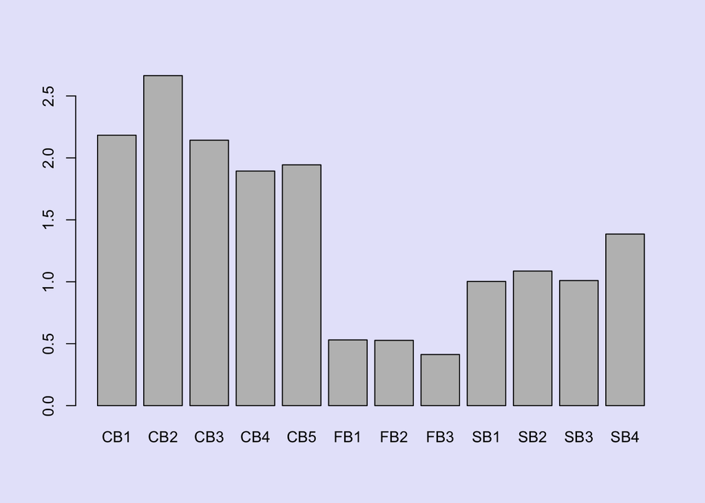

```r
BankData2 %$% tapply(CLPD,bank,mean) %>% barplot()
```

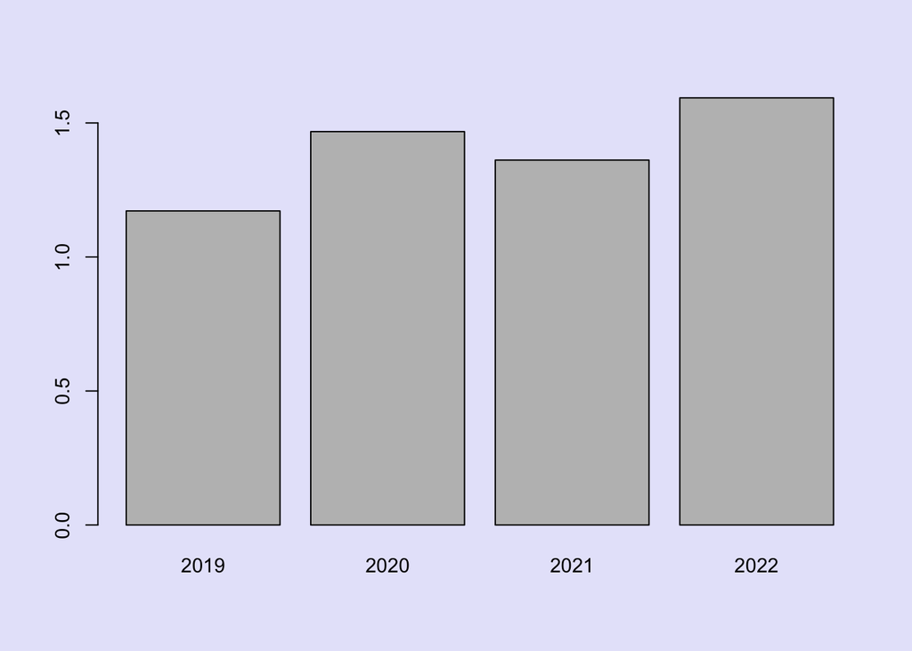

```r
BankData2 %$% tapply(CLPD,year,mean) %>% barplot()
```

### please use ‘BankData1’ to get the same results.

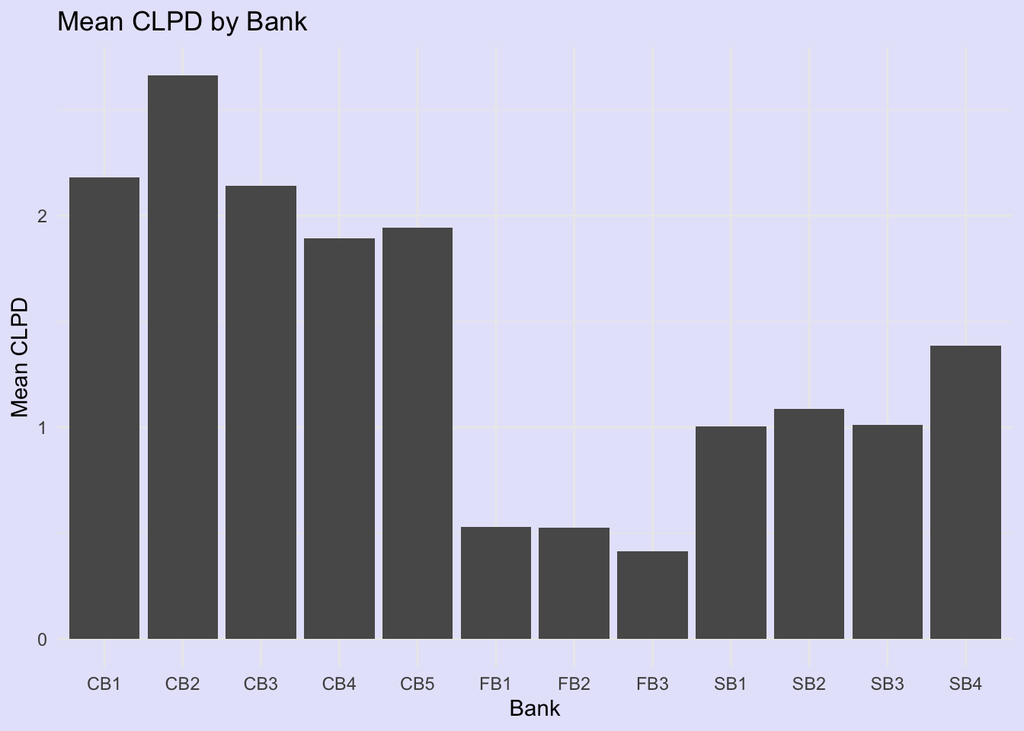

```r
# Group by bank and calculate mean CLPD
bank_mean_CLPD <- BankData1 %>%
  filter(loantype == "CL") %>%
  group_by(bank) %>%
  summarize(mean_CLPD = mean(PD))

# Group by year and calculate mean CLPD
year_mean_CLPD <- BankData1

# Group by year and calculate mean CLPD
year_mean_CLPD <- BankData1 %>%
  filter(loantype == "CL") %>%
  group_by(year) %>%
  summarize(mean_CLPD = mean(PD))

# Create a bar plot for bank_mean_CLPD
ggplot(bank_mean_CLPD, aes(x = bank, y = mean_CLPD)) +
  geom_bar(stat = "identity") +
  theme_minimal() +
  labs(title = "Mean CLPD by Bank",
       x = "Bank",
       y = "Mean CLPD")
```

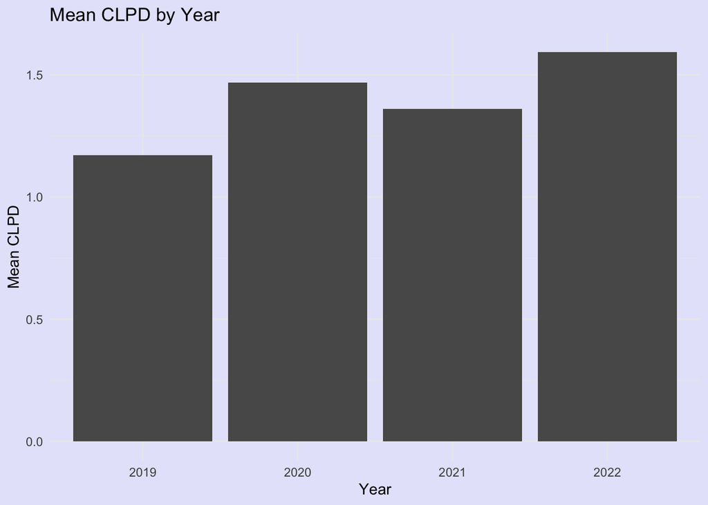

```r
# Create a bar plot for year_mean_CLPD
ggplot(year_mean_CLPD, aes(x = as.factor(year), y = mean_CLPD)) +
  geom_bar(stat = "identity") +
  theme_minimal() +
  labs(title = "Mean CLPD by Year",
       x = "Year",
       y = "Mean CLPD")
```

### Given

```r
BankData1 %$% tapply(PD,list(loantype,year),mean) %>% ptable()
```

|  | 2019 | 2020 | 2021 | 2022 |
| --- | --- | --- | --- | --- |
| BL | 4.490533 | 3.966344 | 3.562083 | 4.614649 |
| CL | 1.171663 | 1.467646 | 1.361393 | 1.593602 |

```r
BankData1 %$% tapply(PD,list(year,loantype),mean) %>% ptable()
```

|  | BL | CL |
| --- | --- | --- |
| 2019 | 4.490533 | 1.171663 |
| 2020 | 3.966344 | 1.467646 |
| 2021 | 3.562083 | 1.361393 |
| 2022 | 4.614649 | 1.593602 |

please use ‘BankData2’ to get the same results.

```r
# Reshape BankData2 to long format
BankData2_long <- BankData2 %>%
  pivot_longer(cols = c("CLPD", "BLPD"),
               names_to = "loantype",
               values_to = "PD") %>%
  mutate(loantype = if_else(loantype == "CLPD", "CL", "BL"))

# Group by loantype and year, calculate mean PD
loantype_year_mean_PD <- BankData2_long %>%
  group_by(loantype, year) %>%
  summarize(mean_PD = mean(PD))
# Pivot the result to a wide format similar to the given table
final_table <- loantype_year_mean_PD %>%
  pivot_wider(names_from = year, values_from = mean_PD)

# Display the final table
final_table %>% ptable()
```

| loantype | 2019 | 2020 | 2021 | 2022 |
| --- | --- | --- | --- | --- |
| BL | 4.490533 | 3.966344 | 3.562083 | 4.614649 |
| CL | 1.171663 | 1.467646 | 1.361393 | 1.593602 |

```r
# Reshape BankData2 to long format
BankData2_long <- BankData2 %>%
  pivot_longer(cols = c("CLPD", "BLPD"),
               names_to = "loantype",
               values_to = "PD") %>%
  mutate(loantype = if_else(loantype == "CLPD", "CL", "BL"))

# Group by year and loantype, calculate mean PD
year_loantype_mean_PD <- BankData2_long %>%
  group_by(year, loantype) %>%
  summarize(mean_PD = mean(PD))
# Pivot the result to a wide format similar to the given table
final_table <- year_loantype_mean_PD %>%
  pivot_wider(names_from = loantype, values_from = mean_PD)

# Display the final table
final_table %>% ptable()
```

| year | BL | CL |
| --- | --- | --- |
| 2019 | 4.490533 | 1.171663 |
| 2020 | 3.966344 | 1.467646 |
| 2021 | 3.562083 | 1.361393 |
| 2022 | 4.614649 | 1.593602 |